[figure not shown]

# Neighbours and trees: tuning models with cross-validation

MY202 · Lab 5

Jonas Weinert

Department of Methodology | London School of Economics and Political Science

29 October 2026

## Lab overview

| Part | Topic | Functions | Mode | Time |
| --- | --- | --- | --- | --- |
|  | Setup |  | together | 3 min |
| I | *k* nearest neighbours and cross-validation | `vfold_cv()`, `tune()`, `recipe()`, `workflow()`, `tune_grid()`, `select_best()` | concept → together, twice, then your turn | 37 min |
| II | A tree, then a forest, then boosting: each a game, code together, your turn | `decision_tree()`, `rpart.plot()`, `rand_forest()`, `boost_tree()` | game → together → your turn, three times | 46 min |
|  | Wrap-up (+ 1 min spare) |  |  | 3 min |

Every block runs the same way: **a concept** with an everyday example, then **code together** (we type it into the notebook; the line number says where), then **your turn** (a timer, tasks and a syntax sheet, then the solutions step by step).

# *k* nearest neighbours

Part I

33,234 survey respondents · two 0–10 questions · PTSD yes or no

## Meet the data: a feature space

I · kNN + CVII · TreesForestsBoostingWrap-up

**Notebook** lines 44–70 `read_csv()`, then the plot of the feature space*run together*

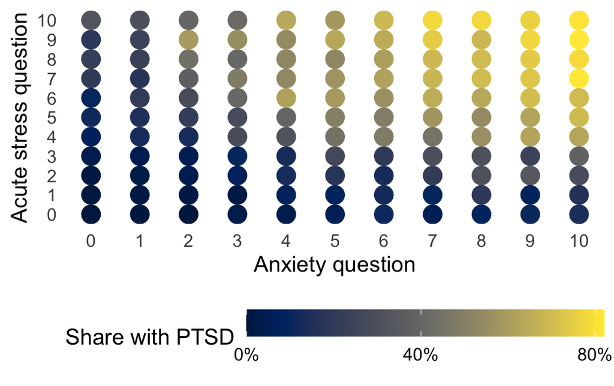

**33,234**people, from an online health questionnaire in Mexico

**34%**have `ptsd`, the outcome: 1 = yes, 0 = no

Two features, both 0–10 `anxiety` and `acute_stress`. Only 121 combinations: each dot is a **cell** of about 275 people, coloured by the share with PTSD.

Where would you draw the line between “yes” and “no”?

## How does an estate agent price a flat?

I · kNN + CVII · TreesForestsBoostingWrap-up

| Flat | Size (m²) | Walk to Tube | Sold within a month? |
| --- | --- | --- | --- |
| A | 58 | 5 min | yes |
| B | 52 | 8 min | yes |
| C | 61 | 7 min | no |
| D | 50 | 4 min | yes |
| E | 57 | 9 min | no |
| F | 95 | 6 min | no |
| G | 55 | 20 min | no |
| H | 40 | 15 min | yes |
| New flat | 55 | 6 min | ? |

55 m², six minutes from the Tube: will it sell within a month? You have last year’s sales.

Find the most similar flats The agent pulls the **comparables**, the sales most like this one: A to E. F is far bigger, G and H far from the Tube.

5 most similarA, B, C, D, E

Their vote3 sold, 2 didn't → **sells**

That is the whole algorithm *k* nearest neighbours: the *k* most similar rows vote. Here k = 5.

## *k* nearest neighbours: the neighbours vote

I · kNN + CVII · TreesForestsBoostingWrap-up

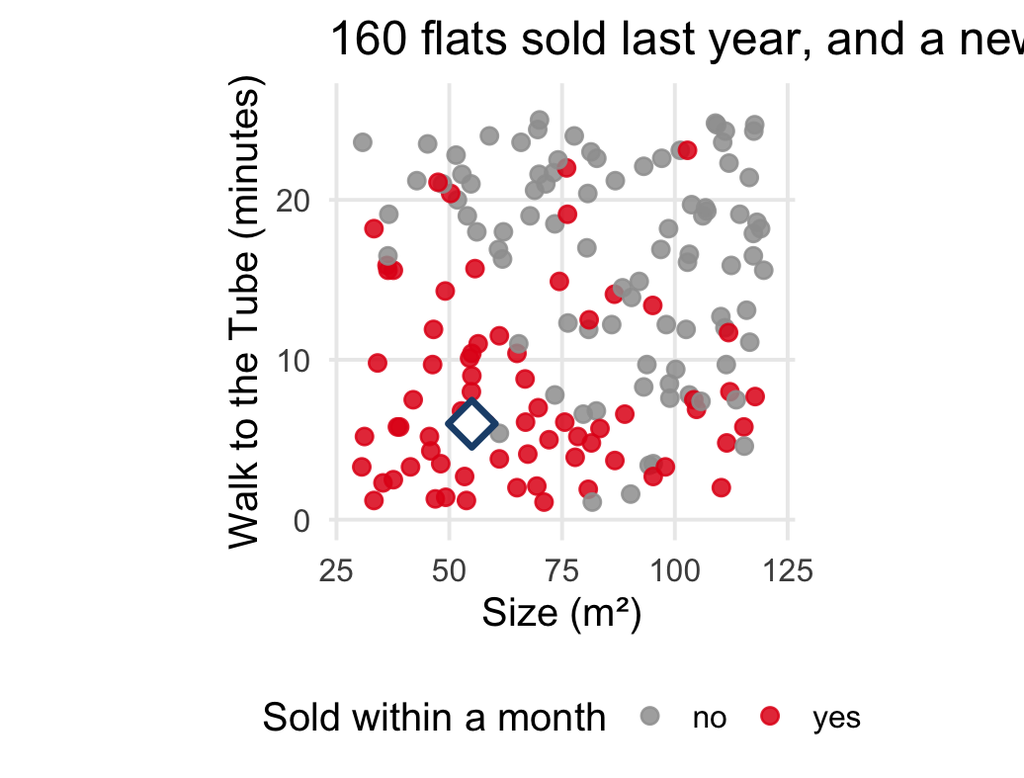

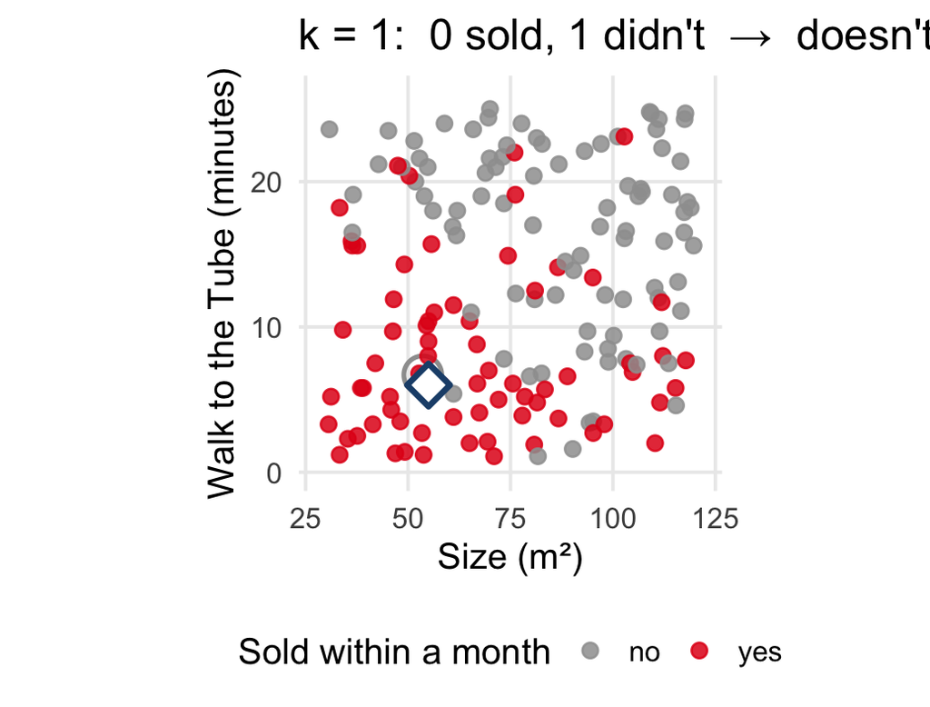

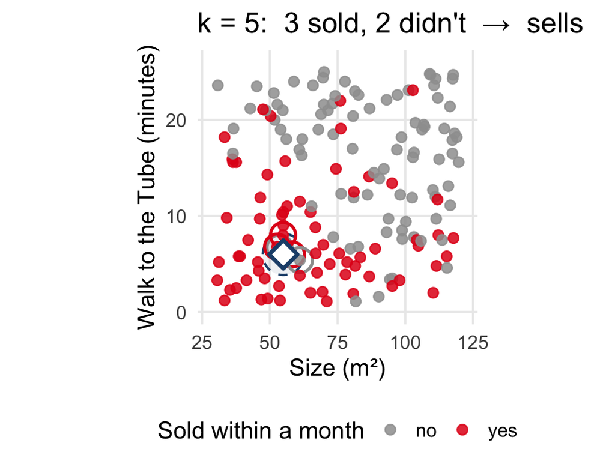

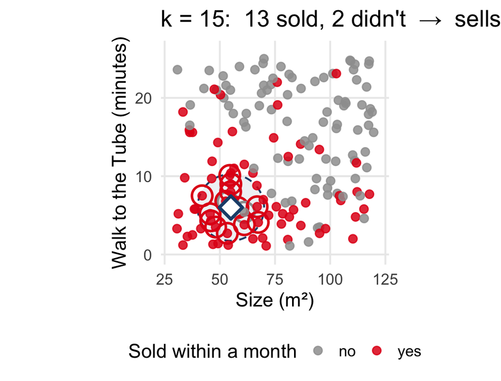

160 flats: each a dot; the diamond is the new one.

k = 1: the single most similar One flat decides. Fast, and at the mercy of one odd sale.

k = 5, k = 15: a wider circle Steadier. Here the answer **flips** between k = 1 and k = 15: same flat, different prediction.

k is a hyperparameter The data can’t say what k should be. Like λ in Lab 3, **we** choose it.

## The boundary depends on k

I · kNN + CVII · TreesForestsBoostingWrap-up

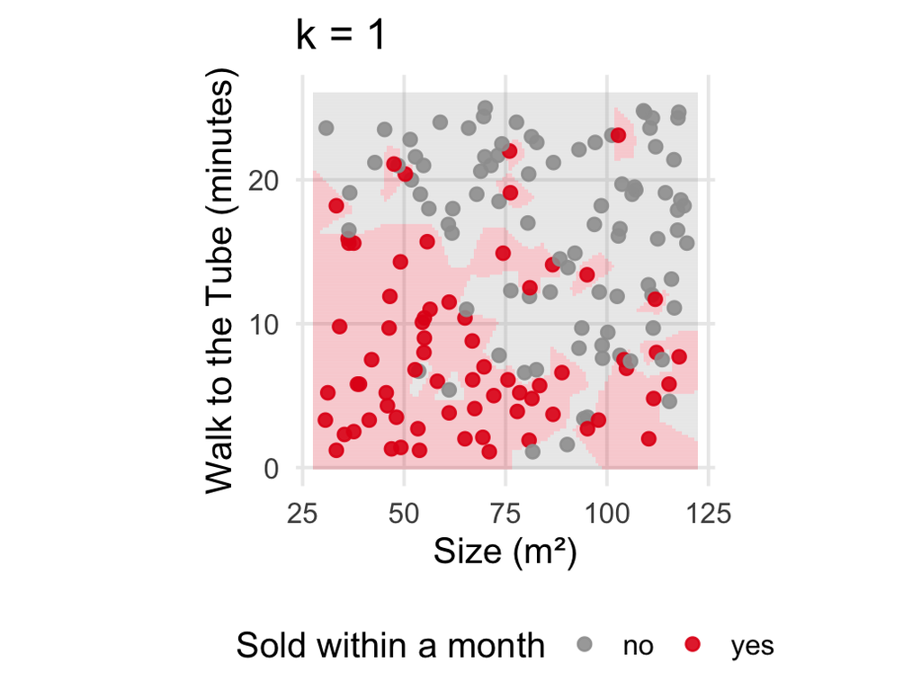

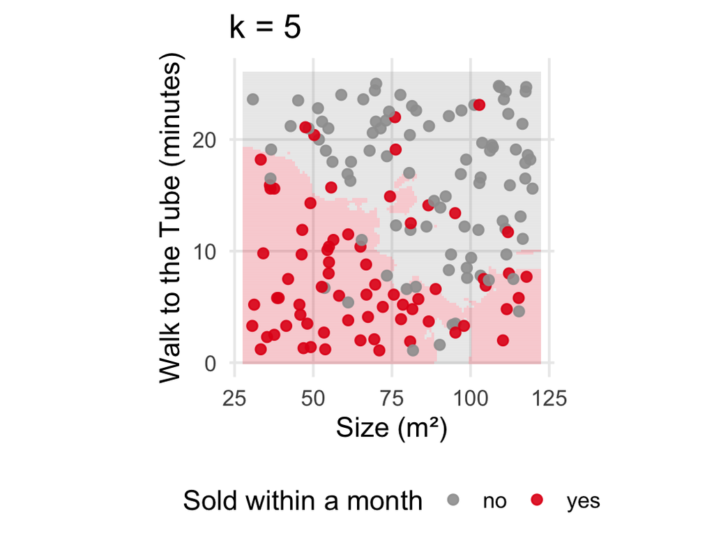

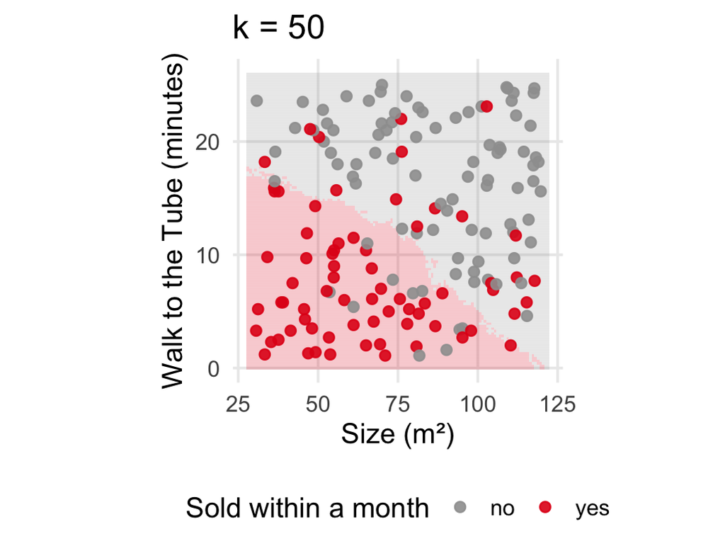

Colour every point by its vote: the **decision boundary**.

k = 1: an island for every flat Every training flat is classified right, and every odd sale becomes a rule.

k = 5, k = 50: smoother More voters average the oddities away; at k = 160 the whole picture is the majority colour.

Which k is right? Not the picture’s call: we need a **score** per k.

## Back to the PTSD data: the boundary depends on k

I · kNN + CVII · TreesForestsBoostingWrap-up

**Solutions notebook** lines 61–79 "for tutors to run": four kNN models fitted in advance; not in the student workbook*demo*

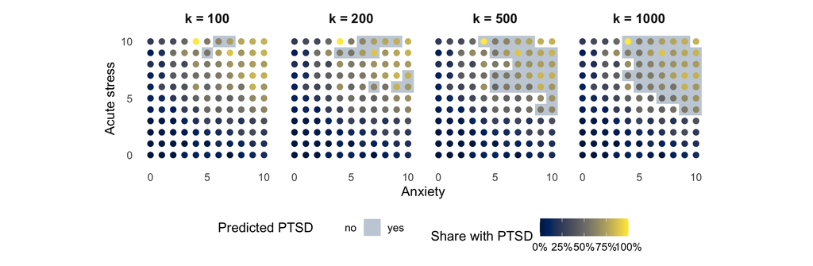

Same picture, real data Anxiety and acute stress instead of size and minutes; shaded = predicted PTSD. Every dot is a cell of about 275 people.

Small k, jagged; large k, smooth k = 100 can’t see past its own cell and barely finds the “yes” region. k = 1,000 draws a broad diagonal band: high anxiety **and** high stress.

Which k, then? The picture can’t say. We need a **fair score** for each k: next.

## Choosing k: the trap

I · kNN + CVII · TreesForestsBoostingWrap-up

Obvious plan: try every k, score each on the 160 flats, keep the best. What goes wrong?

Accuracy on the 160 training flats share of flats classified right

k = 1**100%**

k = 5**82%**

k = 50**82%**

Accuracy on flats held out of the fit 5-fold cross-validation, next slide

k = 1**71%**

k = 5**78%**

k = 50**80%**

k = 1 always wins, and it’s a lie Each flat’s nearest neighbour is **itself**, so k = 1 gets every training flat right. The training score rewards memorising.

The test set can’t choose either Last week’s rule: the test set is the final exam, opened once. Use it to pick k and its score is no longer honest.

Score on flats the fit never saw Hold some training flats back, fit on the rest, score on the held-out ones. Now k = 1 is exposed and k = 50 wins.

## Cross-validation: mock exams

I · kNN + CVII · TreesForestsBoostingWrap-up

*fold 1**fold 2**fold 3**fold 4**fold 5*score for this k

Round 1*mock**fit**fit**fit**fit*score 1

Round 2*fit**mock**fit**fit**fit*score 2

Round 3*fit**fit**mock**fit**fit*score 3

Round 4*fit**fit**fit**mock**fit*score 4

Round 5*fit**fit**fit**fit**mock*score 5

mean of the 5

Five past papers Cut the **training set** into 5 folds, `vfold_cv(ptsd_train, v = 5)`. The test set is not in the picture: it’s the real exam, sealed until the end.

Revise on four, sit the fifth as a mock Each round fits on 4 folds and scores the 5th. Rotate, so every row is a mock question once. Five honest scores, none from the real exam.

Average, then pick One mean score per k. Repeat for every k on the list, keep the best, refit once on all five folds. Then, once, the test set.

## Split and folds

I · kNN + CVII · TreesForestsBoostingWrap-up

**Notebook** lines 107–111 an empty chunk: type the split, then the folds*code together*

set.seed(123) ptsd_split <- initial_split(ptsd, prop = 0.75, strata = ptsd) ptsd_train <- training(ptsd_split) ptsd_test <- testing(ptsd_split) ptsd_cv <- vfold_cv(ptsd_train, v = 5) ptsd_cv

1. **Last week’s split**, stratified on the outcome so both sets have 34% with PTSD.
2. **Cut the training set into folds**: the five past papers. The test set is not involved.
3. **Five of them.** `v`, not `k`: *k* is taken by the neighbours today.

```
#  5-fold cross-validation
# A tibble: 5 × 2
  splits               id
  <list>               <chr>
1 <split [19939/4985]> Fold1
2 <split [19939/4985]> Fold2
3 <split [19939/4985]> Fold3
4 <split [19939/4985]> Fold4
# ℹ 1 more row
```

Read it Five rows, one per round: 19,939 rows to fit on, 4,985 held out.

## The model: leave k open

I · kNN + CVII · TreesForestsBoostingWrap-up

**Notebook** lines 113–119 the empty chunk under "Instantiate k-NN model"*code together*

knn_model <- nearest_neighbor(neighbors = tune()) |> set_mode("classification") |> set_engine("kknn")

1. **Which kind of model**, like `linear_reg()` and `logistic_reg()`.
2. **A placeholder for k**: “cross-validation will fill this in”. The knob from the boundary slide.
3. **Say the job.** kNN can classify (a vote) or predict a number (an average).
4. **The engine**: the `kknn` package finds the neighbours. It loads itself when the model is fitted.

Nothing is fitted yet `knn_model` is a description, not a model. Print it: “neighbors = tune()”.

Next: one more idea before the recipe kNN measures distances. Distances in what units?

## Why normalise? Units decide who is close

I · kNN + CVII · TreesForestsBoostingWrap-up

**Notebook** line 123 "You will need to normalise both predictors as k-NN uses distances." Why?*concept*

Flat F is the same distance from the Tube but 40 m² bigger. Flat G is the same size but 14 minutes further. Which is more similar to the new flat?

m² and minutesF: 40 · G: 14 G is "closer"

ft² and minutesF: 431 · G: 14 G, by a mile

m² and secondsF: 40 · G: 840 now F is closer

In standard deviationsF: 40 / 26 = 1.5 · G: 14 / 7.4 = 1.9 F is closer

The answer depends on the units Distance adds the two gaps together, so whichever feature has the bigger numbers wins. That can’t be right.

So measure every feature in SDs Subtract the mean, divide by the standard deviation: “how unusual is this gap?” That’s `step_normalize()` in the recipe, and it’s why kNN needs one.

## Recipe and workflow

I · kNN + CVII · TreesForestsBoostingWrap-up

**Notebook** lines 121–129 the note at line 123 says why: "k-NN uses distances"*code together*

knn_rec <- recipe(ptsd ~ ., data = ptsd_train) |> step_normalize(all_numeric_predictors()) wf_knn <- workflow() |> add_model(knn_model) |> add_recipe(knn_rec)

1. **A recipe**: the formula **plus** the pre-processing to run before fitting.
2. **Every feature in standard deviations**, the previous slide. Mean 0, SD 1, so distance is fair.
3. **Bundle model and recipe.** `fit()` on a workflow runs both, and new data gets exactly the same treatment.

## Metrics, candidates, and the tuning run

I · kNN + CVII · TreesForestsBoostingWrap-up

**Notebook** lines 133–152 metrics and grid in the chunk at 133; `tune_grid()` is sketched at 143–150: fill the four brackets, remove the `#`*code together*

class_metrics <- metric_set(recall, precision, f_meas) grid_knn <- tibble(neighbors = c(100, 500, 1000, 3000)) doParallel::registerDoParallel() knn_model_cv <- tune_grid(wf_knn, resamples = ptsd_cv, metrics = class_metrics, grid = grid_knn, control = control_resamples(event_level = "second"))

1. **Three scores**, as in Lab 4. We pick by F1.
2. **The candidates**: one column per knob, one row per value to try.
3. **Use all the cores**: the fits can run side by side.
4. **Every candidate on every fold: fit, score.** 4 × 5 = 20 fits.
5. **The five rounds** from the folds slide.
6. **Score the 1s**, as last week, passed through `control`.

## While it runs

I · kNN + CVII · TreesForestsBoostingWrap-up

`tune_grid()` is running. How many kNN models is it fitting, and which rows does each one see?

**A**4 models, one per k, each on the whole training set

**B**20 models: each k on each of the 5 rounds, fitted on 4 folds and scored on the 5th

**C**5 models, one per fold

**D**1 model, the best one

**B.** 4 candidates × 5 rounds. None of them is the final model: once the best k is known, the workflow is fitted **once more on the whole training set** (that's `finalize_workflow() |> fit()` in the exercise), and that one meets the test set.

## Exercises: Part I

Part I · lines 156–198

1. **Line 158, given:** first print `knn_model_cv |> collect_metrics()` on its own: one row per k and metric. Then run the chunk: the mean metric against k, one colour per metric.
2. **Lines 178–185, given:** `select_best()` by F1, then finalise the workflow and **fit on the whole training set**. Half a minute.
3. **Line 192, yours:** F1 on the test set, and on the training set for comparison.
4. **Line 198:** which k won? Any overfitting?

Syntax you need

```r
knn_model_cv |> collect_metrics()   # mean of the 5 rounds, per k

knn_model_cv |> collect_metrics() |>
  mutate(neighbors = as.factor(neighbors)) |>  # evenly spaced
  ggplot(aes(neighbors, mean, colour = .metric,
             group = .metric)) +                # one line per metric
  geom_point() + geom_line(linetype = "dashed")

highest_f1 <- select_best(knn_model_cv, metric = "f_meas")

knn_model_final <- wf_knn |>
  finalize_workflow(highest_f1) |>   # fill in tune()
  fit(ptsd_train)                    # the one model we keep

knn_model_final |>
  augment(new_data = ptsd_test) |>   # as Lab 4
  f_meas(truth = ptsd, estimate = .pred_class,
         event_level = "second")
```

**Stuck?**

- `group = .metric` is what joins the dots: without it, no lines
- Test F1 near 0.85? `event_level = "second"` is missing

## Solutions: Part I

```r
knn_model_cv |> collect_metrics()

knn_model_cv |> collect_metrics() |>
  mutate(neighbors = as.factor(neighbors)) |>
  ggplot(aes(neighbors, mean, colour = .metric,
             group = .metric)) +
  geom_point(size = 2.5) + geom_line(linetype = "dashed")

highest_f1 <- select_best(knn_model_cv, metric = "f_meas")

knn_model_final <- wf_knn |>
  finalize_workflow(highest_f1) |>
  fit(ptsd_train)

knn_model_final |>
  augment(new_data = ptsd_train) |>
  f_meas(truth = ptsd, estimate = .pred_class, event_level = "second")

knn_model_final |>
  augment(new_data = ptsd_test) |>
  f_meas(truth = ptsd, estimate = .pred_class, event_level = "second")
```

Read the cross-validated scores, pick the best k, refit once, then the test set.

12 rows: 4 values of k × 3 metrics. `mean` is the average of the 5 rounds, `n` says 5, `std_err` how much the rounds disagreed. Shown wide here to fit.

```
# A tibble: 4 × 4
  neighbors f_meas precision recall
      <dbl>  <dbl>     <dbl>  <dbl>
1       100  0.085     0.67   0.046
2       500  0.625     0.7    0.565
3      1000  0.733     0.705  0.763
4      3000  0.736     0.704  0.771
```

Recall climbs with k; precision is flat; F1 is best at 3,000 and 1,000 is almost as good. k = 100 is useless here (recall 0.05).

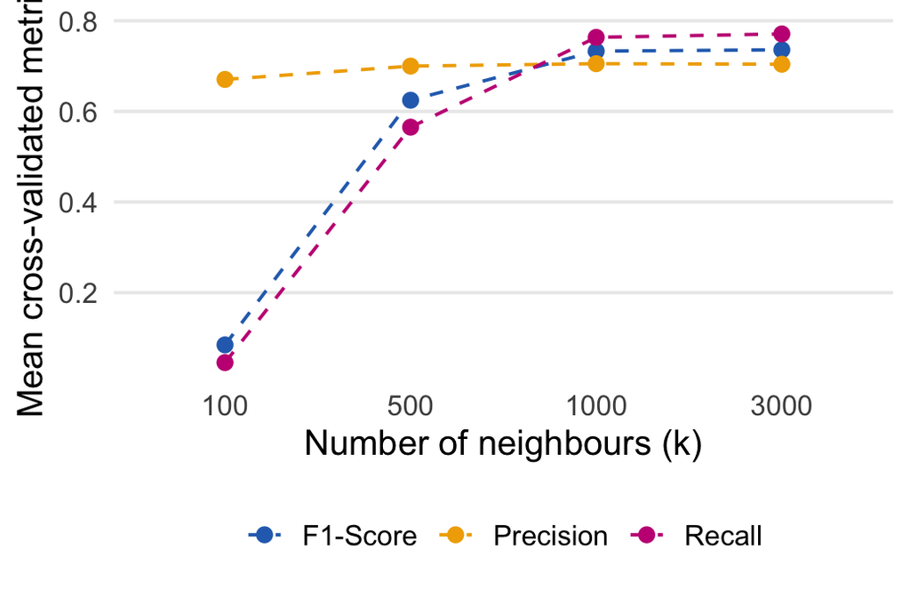

`select_best()` returns the winning row of the grid: `neighbors =` 3,000.

```
# A tibble: 1 × 2
  neighbors .config
      <dbl> <chr>
1      3000 pre0_mod4_post0
```

`finalize_workflow()` swaps `tune()` for 3,000; `fit()` then fits that model **once, on all 24,924 training rows**. The 20 tuning fits are gone.

```
== Workflow [trained] ==================
Preprocessor: Recipe
Model: nearest_neighbor()

  neighbors = 3000
  kernel = optimal
  ...
```

Training F1 0.736, test F1 0.737, cross-validated 0.736: all the same. **No overfitting**, and the cross-validated score predicted the test score well.

```
# A tibble: 2 × 4
  set   .metric .estimator .estimate
  <chr> <chr>   <chr>          <dbl>
1 train f_meas  binary         0.736
2 test  f_meas  binary         0.737
```

## Part I: what did we learn?

I · kNN + CVII · TreesForestsBoostingWrap-up

F1 for the chosen k = 3,000 three sets of rows, three jobs

cross-validated**0.736**

training set**0.736**

test set**0.737**

Simplest rule"predict the majority of your own cell" training set

Its test F10.739

Cross-validation did its job It ranked the candidates on training rows only, and its score for the winner matched the test set. The test set was opened once.

Why large k won Every dot is a cell of 275 people. k = 100 can’t see past its own cell; k = 3,000 averages a neighbourhood of cells. With two 0–10 features, **the cell majority is already as good as it gets**: F1 0.739.

kNN has no coefficients Nothing to read off, no “per unit of anxiety”. Flexible, and slow to predict. Trees, next, are flexible **and** readable.

# Trees, forests, boosting

Part II

2,904 US counties · 2008–2018 · the weekly cost of childcare

## Meet the data

I · kNN + CVII · TreesForestsBoostingWrap-up

**Notebook** lines 296–318 `read_csv()`, the split by year and the recipe: all given, run them now*run together*

**23,593**county-years: 2,904 counties over 11 years

**52**features: income, jobs, families, population

**$97**median weekly price of centre-based care, `mcsa`

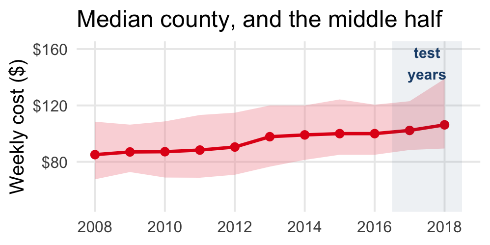

Back to regression A dollar outcome: Lab 3’s **RMSE** and **R²**, and `set_mode("regression")` on every model.

Time is in the data Each county appears year after year. Train on 2008–2016, test on 2017–2018: **predict the future**.

## Split by time

I · kNN + CVII · TreesForestsBoostingWrap-up

**Notebook** lines 303–309 already run with `read_csv()`: what the two `filter()` lines did*read together*

childcare_train <- childcare |> filter(study_year <= 2016) childcare_test <- childcare |> filter(study_year > 2016)

1. **Train on the past**: 2008–2016, 18,797 county-years.
2. **Test on the future**: 2017–2018, 4,796. No `initial_split()`, no seed: the calendar decides.

*08**09**10**11**12**13**14**15**16**17**18*

Split*fit**fit**fit**fit**fit**fit**fit**fit**fit**test**test*final exam

Folds would need the same care `vfold_cv()` shuffles rows. With years: fit on the past, score the next (`sliding_period()`). Not needed today.

Why not a random split? Each county appears every year. A random split puts a county’s 2017 row in training and its 2018 row in the test set: the model has nearly seen the answer, and the score flatters it.

The honest question Next year’s prices from this year’s data: **predict the future**. The test years are a little harder, because prices rose.

## Who’s a Swiftie? You may ask one question

I · kNN + CVII · TreesForestsBoostingWrap-up

| Person | Age | Likes pop | Plays guitar | Enjoys lyrics | Follows trends | Swiftie? |
| --- | --- | --- | --- | --- | --- | --- |
| **A** | 19 | yes | no | yes | yes | Swiftie |
| **B** | 27 | yes | yes | yes | no | Swiftie |
| **C** | 20 | no | yes | yes | no | not |
| **D** | 24 | yes | no | yes | yes | Swiftie |
| **E** | 22 | no | yes | yes | no | not |
| **F** | 29 | no | yes | no | yes | not |
| **G** | 18 | yes | no | yes | yes | Swiftie |
| **H** | 21 | no | no | yes | no | not |
| **I** | 26 | yes | yes | yes | yes | Swiftie |
| **J** | 25 | no | no | no | yes | not |
| **K** | 23 | yes | yes | no | no | not |
| **L** | 31 | no | no | yes | yes | Swiftie |

Ask **one** yes/no question, then guess “Swiftie” or “not” for each group. Which question gets the most right?

Plays guitar?8 of 12 right

Age under 20?8 of 12

Enjoys lyrics?9 of 12

Follows trends?9 of 12

Likes pop?10 of 12 pop fans 5 of 6 · rest 1 of 6

The first split of a decision tree Try every question (every cut-off, for age). Keep the one that **sorts cleanest**.

## Then ask again, inside each group

I · kNN + CVII · TreesForestsBoostingWrap-up

Likes pop?

yes · A B D G I KEnjoys lyrics?

no · C E F H J L**not a Swiftie**5 of 6 right (L is a Swiftie)

yes**Swiftie**A B D G I: 5 of 5

no**not**K: 1 of 1

The tree11 of 12 right, with two questions

Pop fans: one more question Among the six pop fans, “enjoys lyrics?” sorts all six. K is the pop fan who doesn’t care about lyrics.

Each group gets its own question The second question is asked **inside** a group, not of everyone. Non-pop fans: no question tidies them up, so the guess stays “not”.

A decision tree A flow chart of yes/no questions, a guess in every **leaf**. Readable by anyone: that’s its big selling point.

## What about L, the Swiftie who isn’t a pop fan?

I · kNN + CVII · TreesForestsBoostingWrap-up

The six non-pop fans

| Person | Age | Plays guitar | Enjoys lyrics | Follows trends | Swiftie? |
| --- | --- | --- | --- | --- | --- |
| **C** | 20 | yes | yes | no | not |
| **E** | 22 | yes | yes | no | not |
| **F** | 29 | yes | no | yes | not |
| **H** | 21 | no | yes | no | not |
| **J** | 25 | no | no | yes | not |
| **L** | 31 | no | yes | yes | Swiftie |

Age 30 or over?finds L, and only L 12 of 12

Can a third question find L too?

Yes: one does L is 31, the oldest. “Age 30 or over?” makes the tree perfect on the table.

Would you bet that non-pop fans over 30 are Swifties?

No: a question invented for one person Ask until every leaf is pure and the tree **memorises** the table: overfitting. Real trees stop early (`min_n`, `cost_complexity`).

## Same game, with prices

I · kNN + CVII · TreesForestsBoostingWrap-up

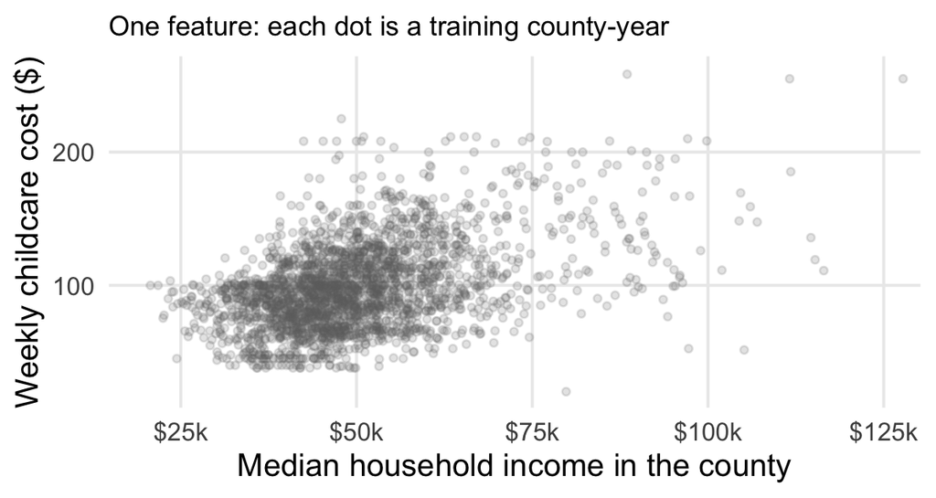

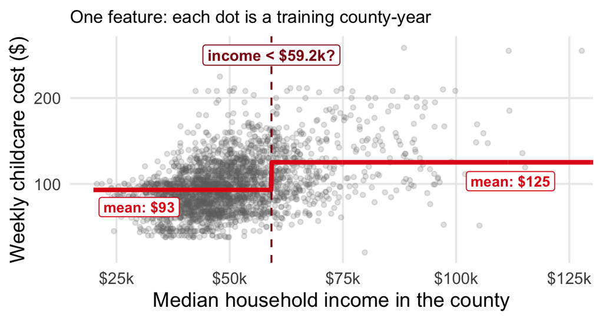

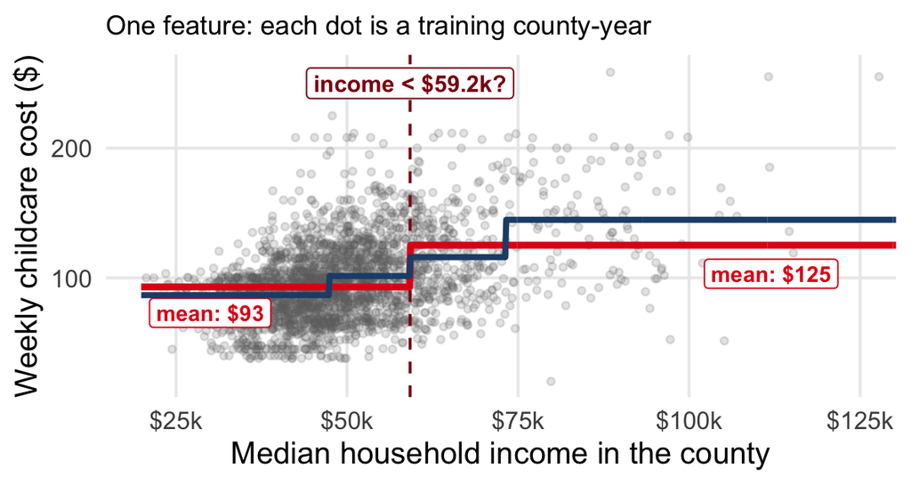

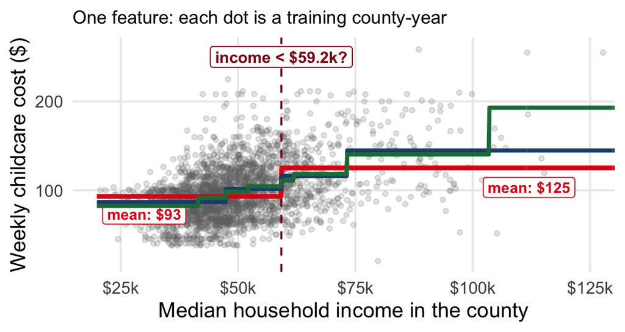

The question is a cut-off Try every income as a cut-off, like age in the game. The cleanest: **income below $59.2k?**

The guess is the mean Each side predicts its **average** price: $93 and $125. “Cleanest” = the smallest squared error, Lab 3’s RMSE.

Ask again inside each side A **staircase**. `decision_tree()` plays this on all 52 columns.

## Your first tree, together

I · kNN + CVII · TreesForestsBoostingWrap-up

**Notebook** lines 314–327 the recipe (already run), then the Task 1 chunk: type the spec and the fit*code together*

childcare_rec <- recipe(mcsa ~ ., data = childcare_train) |> update_role(starts_with(c("county", "state")), new_role = "id") dt_model <- decision_tree() |> set_mode("regression") |> set_engine("rpart") dt_fit <- workflow() |> add_recipe(childcare_rec) |> add_model(dt_model) |> fit(data = childcare_train)

1. **Keep but don’t use**: county and state names and codes become `id` labels, out of the model. The year stays in.
2. **A tree**, with `rpart`’s built-in brakes.
3. **A price**, so every leaf predicts a mean.
4. **No `tune()`, so fit straight away**: Part I’s pattern without the folds.

No normalising this time A tree asks “income below $47.7k?”. A cut-off doesn’t care about units, so no `step_normalize()`. kNN measured distances; trees don’t.

One recipe, three models The forest and the boosted trees reuse `childcare_rec`. Only the model line changes.

## Exercises: Task 1, draw and score the tree

Part II · Task 1 · lines 324–338

1. **Line 330, given:** draw `dt_fit` with `rpart.plot()`. Find the first question.
2. **Line 333, given:** `metric_set(rsq, rmse)`.
3. **Line 335, yours:** score the training set and the test set with it.
4. **Line 338:** what does the tree show? Which variables matter?

Syntax you need

```r
rpart.plot(extract_fit_engine(dt_fit),  # the rpart tree inside
           roundint = FALSE)

regress_metrics <- metric_set(rsq, rmse)  # Lab 3's scores

dt_fit |>
  augment(new_data = childcare_train) |>  # adds .pred
  regress_metrics(mcsa, .pred)            # truth, estimate

dt_fit |>
  augment(new_data = childcare_test) |>
  regress_metrics(mcsa, .pred)
```

**Stuck?**

- *could not find function “rpart.plot”*: run the library chunk at line 27
- *object ‘dt_fit’ not found*: run the spec and the fit first

## Solutions: Task 1

```r
rpart.plot(extract_fit_engine(dt_fit), roundint = FALSE)

regress_metrics <- metric_set(rsq, rmse)

dt_fit |>
  augment(new_data = childcare_train) |>
  regress_metrics(mcsa, .pred)

dt_fit |>
  augment(new_data = childcare_test) |>
  regress_metrics(mcsa, .pred)
```

Draw it, then score: training set, then test set.

The Swiftie game on 52 columns. First question `one_race_a < 2.2`, then income. 6 columns used, 9 leaves from $80 to $224.

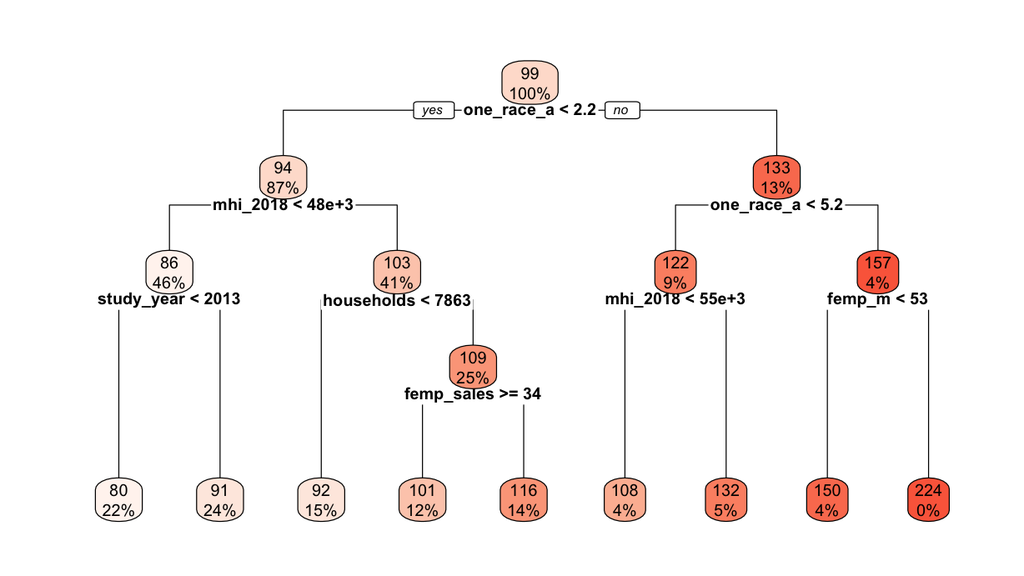

Training set: RMSE 27.5 dollars a week, R² 0.32. 9 numbers can only explain so much.

```
# A tibble: 2 × 3
  .metric .estimator .estimate
  <chr>   <chr>          <dbl>
1 rsq     standard       0.320
2 rmse    standard      27.5
```

Test set: RMSE 31.5, R² 0.32. A little worse than training; predicting the mean would give 39.1. **The baseline the next two models must beat.**

```
# A tibble: 2 × 3
  .metric .estimator .estimate
  <chr>   <chr>          <dbl>
1 rsq     standard       0.323
2 rmse    standard      31.5
```

## A forest: ask three friends who each know less

I · kNN + CVII · TreesForestsBoostingWrap-up

Friend 1saw A B C D E G H I  
may ask: plays guitar or follows trends

Follows trends?

yes · A D G I**Swiftie**4 of 4 right

no · B C E H**not**3 of 4 right

Mia: Swiftie

Friend 2saw A B E F I J K L  
may ask: follows trends or age

Age 26 or over?

yes · B F I L**Swiftie**3 of 4 right

no · A E J K**not**3 of 4 right

Mia: not

Friend 3saw A B D E F I K L  
may ask: age or enjoys lyrics

Enjoys lyrics?

yes · A B D E I L**Swiftie**5 of 6 right

no · F K**not**2 of 2 right

Mia: Swiftie

Each friend sees less **8 of the 12 people** (a random resample) and **2 of the 5 questions** (random columns). Different evidence, a different first question.

Mia: 22, not a pop fan, plays guitar, enjoys lyrics, follows trends Votes: Swiftie, not, Swiftie. **Swiftie**, 2 to 1. Our one tree said “not”: not a pop fan.

That is a random forest 1,000 such friends. Each tree on a **resample** of the rows, each split from a few random columns (`mtry`). They **vote**; for a price, they **average**.

## A forest, with prices

I · kNN + CVII · TreesForestsBoostingWrap-up

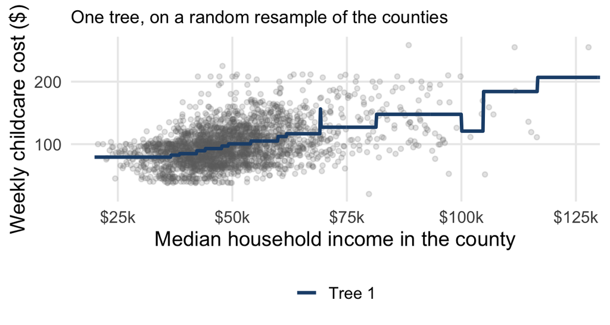

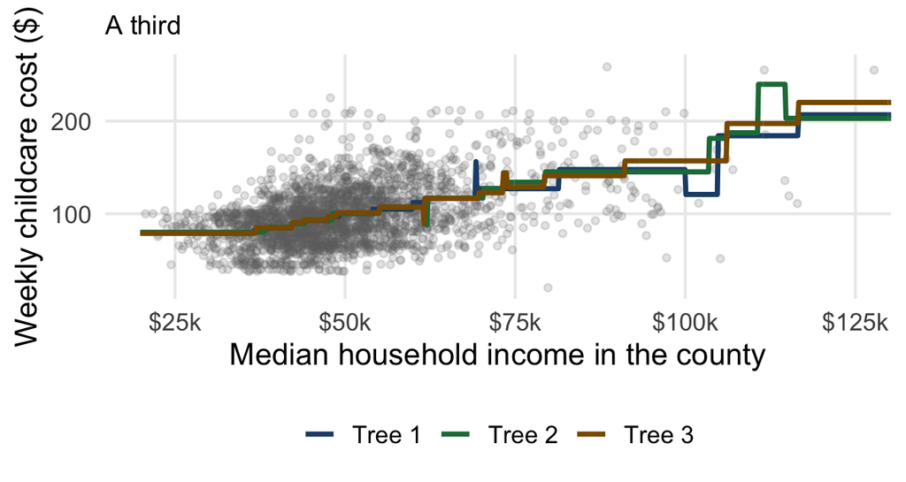

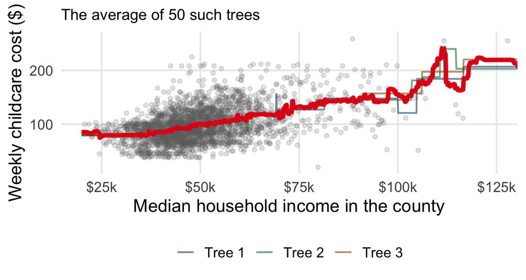

One friend, one resample Draw the counties at random, with replacement; grow a tree. One staircase.

Three friends, three staircases Each resample has different counties, so the steps land in different places.

Average them: smooth Each tree’s odd steps cancel out in the average of 50. The forest overfits far less than any one deep tree.

## The forest, together

I · kNN + CVII · TreesForestsBoostingWrap-up

**Notebook** lines 348–351 the Task 2 sketch: fill in the brackets, remove the `#`*code together*

rf_model <- rand_forest(mtry = round(sqrt(52), 0), trees = 1e3) |> set_mode("regression") |> set_engine("ranger", num.threads = parallel::detectCores() - 1)

1. **Many trees, averaged.** Same spec–workflow–fit pattern as the tree.
2. **`mtry`: columns per split.** Each split may look at 7 random columns of the 52, the friends’ “2 of 5”. √52 ≈ 7 is a rule of thumb.
3. **`trees`: how many friends.** 1,000; more only costs time.
4. **The engine.** `ranger` grows the trees; `num.threads` uses all cores but one, about 20 seconds instead of a minute.

## Exercises: Task 2, fit and score the forest

Part II · Task 2 · lines 347–358

1. **Line 353:** fit `rf_model` in a workflow with `childcare_rec`; call it `rf_fit`. Takes about 20 seconds.
2. **Line 355:** score the training set and the test set.
3. **Line 358:** better predictions than the tree? Does it help with overfitting?

Task 1’s pattern, new model

```r
rf_fit <- workflow() |>
  add_recipe(childcare_rec) |>
  add_model(rf_model) |>        # was dt_model
  fit(data = childcare_train)

rf_fit |>
  augment(new_data = childcare_test) |>
  regress_metrics(mcsa, .pred)
# and the same with childcare_train
```

**Stuck?** Training RMSE far below the test one? That’s normal for a forest: see the solution.

## Solutions: Task 2

```r
rf_fit <- workflow() |>
  add_recipe(childcare_rec) |>
  add_model(rf_model) |>
  fit(data = childcare_train)

rf_fit |> augment(new_data = childcare_train) |>
  regress_metrics(mcsa, .pred)
rf_fit |> augment(new_data = childcare_test) |>
  regress_metrics(mcsa, .pred)
```

Fit, then score both sets.

1,000 trees, each on a resample, each split choosing among 7 random columns. About 20 seconds.

```
== Workflow [trained] ==================
Preprocessor: Recipe
Model: rand_forest()

Ranger result
  Type:            Regression
  Number of trees: 1000
  Mtry:            7
  ...
```

Test RMSE 23.9 against the tree’s 31.5: **much better**. Training 6.6: tiny, and that’s normal. Every row was in most trees’ resamples, so the forest has seen it. Judge it on the test set.

```
# A tibble: 4 × 4
  set   .metric .estimator .estimate
  <chr> <chr>   <chr>          <dbl>
1 train rsq     standard       0.976
2 train rmse    standard       6.61
3 test  rsq     standard       0.64
4 test  rmse    standard      23.9
```

## Boosting: a relay, each friend fixes the last one’s mistakes

I · kNN + CVII · TreesForestsBoostingWrap-up

| Person | Swiftie? | Friend 1 likes pop? | Friend 2 enjoys lyrics? | Friend 3 follows trends? | Together 2 of 3 |
| --- | --- | --- | --- | --- | --- |
| **A** | Swiftie | Swiftie ✓ | Swiftie ✓ | Swiftie ✓ | Swiftie ✓ |
| **B** | Swiftie | Swiftie ✓ | Swiftie ✓ | not ✗ | Swiftie ✓ |
| **C** | not | not ✓ | Swiftie ✗ | not ✓ | not ✓ |
| **D** | Swiftie | Swiftie ✓ | Swiftie ✓ | Swiftie ✓ | Swiftie ✓ |
| **E** | not | not ✓ | Swiftie ✗ | not ✓ | not ✓ |
| **F** | not | not ✓ | not ✓ | Swiftie ✗ | not ✓ |
| **G** | Swiftie | Swiftie ✓ | Swiftie ✓ | Swiftie ✓ | Swiftie ✓ |
| **H** | not | not ✓ | Swiftie ✗ | not ✓ | not ✓ |
| **I** | Swiftie | Swiftie ✓ | Swiftie ✓ | Swiftie ✓ | Swiftie ✓ |
| **J** | not | not ✓ | not ✓ | Swiftie ✗ | not ✓ |
| **K** | not | Swiftie ✗ | not ✓ | not ✓ | not ✓ |
| **L** | Swiftie | not ✗ | Swiftie ✓ | Swiftie ✓ | Swiftie ✓ |

Friend 1 plays the game “Likes pop?”: 10 of 12, wrong about **K and L**.

Friend 2: “K and L count 4×” The best question now gets K and L right: **lyrics?** Wrong about C, E, H.

Friend 3: “C, E, H, K, L count 4×” **Trends?** gets those five right. Wrong about B, F, J.

Together: 12 of 12 Nobody is wrong twice. **Boosting**: small trees **in turn**, each aimed at the last ones’ mistakes, then combined.

## Boosting, with prices

I · kNN + CVII · TreesForestsBoostingWrap-up

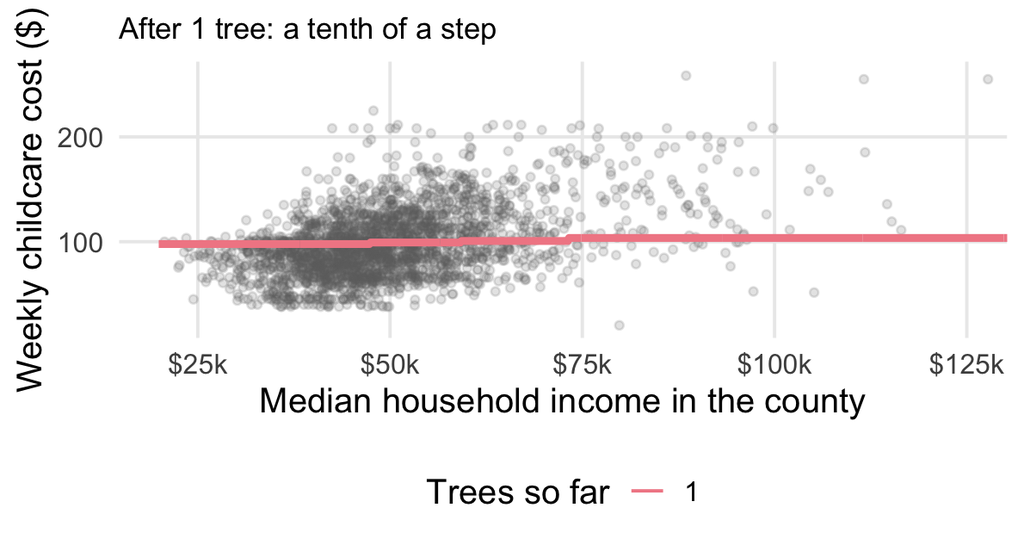

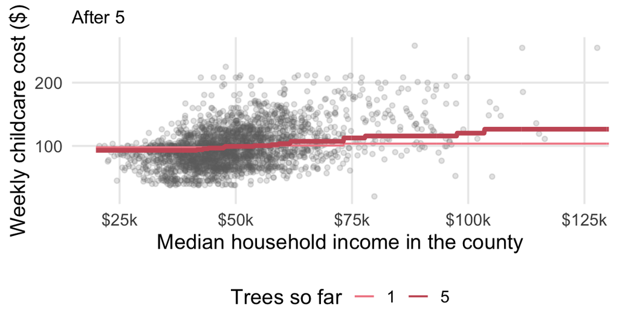

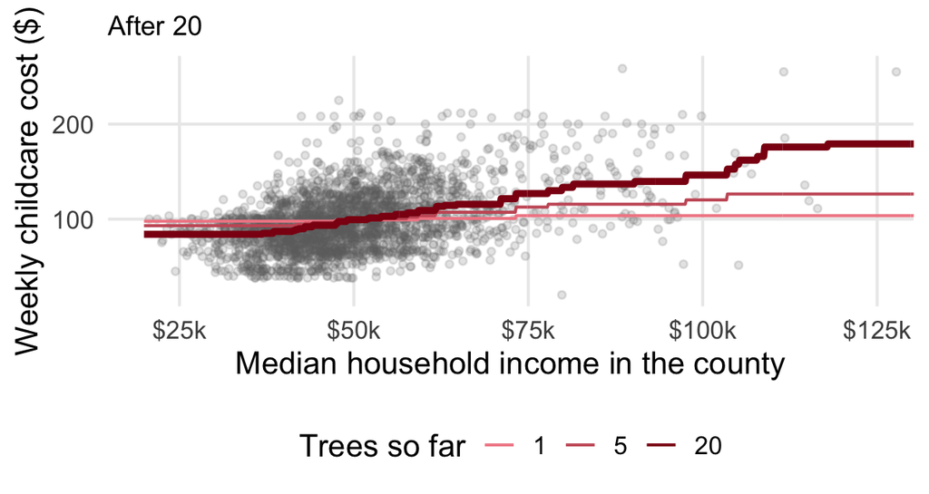

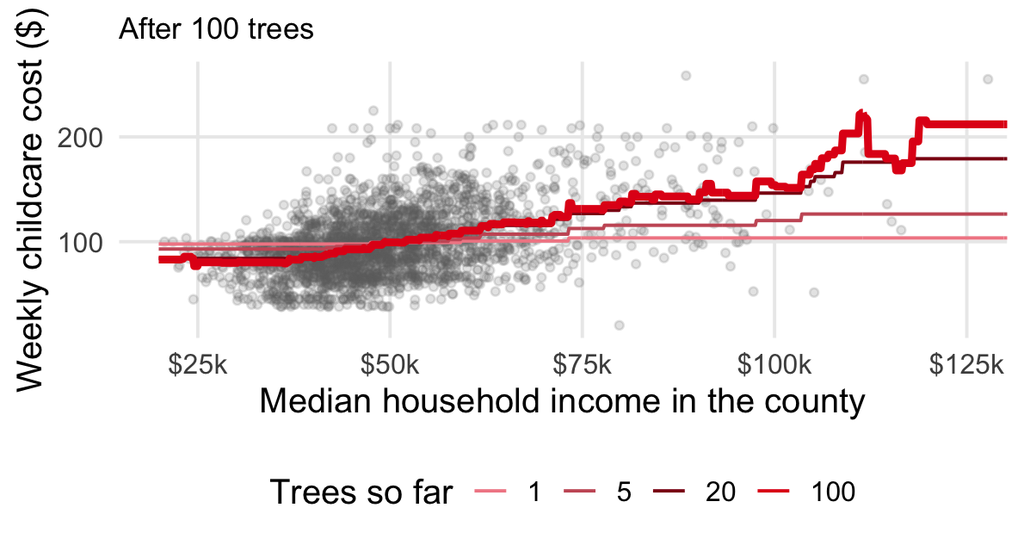

With a number, “the mistakes” are the leftovers Each small tree predicts how far off the trees so far still are, county by county.

Add only a tenth Each tree’s answer is added with a small say: `learn_rate = 0.1`. One step at a time, so no single tree can wreck it.

After 100 trees The relay has found the shape. Keep going for ever and it starts to chase single counties, like the question for L.

## Boosting, together

I · kNN + CVII · TreesForestsBoostingWrap-up

**Notebook** lines 365–372 the Task 3 sketch: fill in the brackets, remove the `#`*code together*

xgb_model <- boost_tree( mtry = round(sqrt(52), 0), trees = 1000, learn_rate = 0.1 ) |> set_mode("regression") |> set_engine("xgboost")

1. **Small trees in a relay**, summed. Same pattern again; `mtry` as in the forest.
2. **`trees`: the length of the relay.** 1,000 legs.
3. **`learn_rate`: each tree’s say.** A tenth of its answer is added.
4. **The engine**: XGBoost, the boosting library that wins most competitions on tables of data.

## Exercises: Tasks 3 and 4, boost and compare

Part II · Tasks 3–4 · lines 364–390

1. **Line 374:** fit `xgb_model` as `xgb_fit`; score both sets (376). A few seconds.
2. **Line 380:** better than the forest? Overfitting?
3. **Lines 386–390, Task 4:** test-set RMSE for all three models in one table, then a bar chart.

Task 4: three fits, one table

```r
model_results <-
  list("Decision Tree" = dt_fit,
       "Random Forest" = rf_fit,
       "XGBoost"       = xgb_fit) |>
  map_dfr(~ augment(.x, new_data = childcare_test),
          .id = "model") |>          # list names → a column
  group_by(model) |>
  regress_metrics(mcsa, .pred) |>    # one score per model
  filter(.metric == "rmse")

ggplot(model_results,
       aes(reorder(model, .estimate), .estimate)) +
  geom_col() + coord_flip()
```

**Stuck?** `map_dfr()` is Lab 4’s threshold sweep: a list in, one stacked table out.

## Solutions: Task 3

```r
xgb_fit <- workflow() |>
  add_recipe(childcare_rec) |>
  add_model(xgb_model) |>
  fit(data = childcare_train)

xgb_fit |> augment(new_data = childcare_train) |>
  regress_metrics(mcsa, .pred)
xgb_fit |> augment(new_data = childcare_test) |>
  regress_metrics(mcsa, .pred)
```

Fit, then score both sets.

1,000 small trees in sequence, each adding a tenth of its correction. A few seconds.

```
== Workflow [trained] ==================
Preprocessor: Recipe
Model: boost_tree()

Main Arguments:
  mtry = 7
  trees = 1000
  learn_rate = 0.1

Computational engine: xgboost
  ...
```

Test RMSE 22.3, the best of the three (forest 23.9). Training 3.6: the same big gap as the forest, for the same reason.

```
# A tibble: 4 × 4
  set   .metric .estimator .estimate
  <chr> <chr>   <chr>          <dbl>
1 train rsq     standard       0.989
2 train rmse    standard       3.59
3 test  rsq     standard       0.655
4 test  rmse    standard      22.3
```

## Solutions: Task 4

```r
model_results <-
  list(
    "Decision Tree" = dt_fit,
    "Random Forest" = rf_fit,
    "XGBoost"       = xgb_fit
  ) |>
  map_dfr(~ .x |> augment(new_data = childcare_test),
          .id = "model") |>
  group_by(model) |>
  regress_metrics(mcsa, .pred) |>
  filter(.metric == "rmse")

ggplot(model_results,
       aes(x = reorder(model, .estimate),
           y = .estimate, fill = model)) +
  geom_col(show.legend = FALSE) +
  geom_text(aes(label = round(.estimate, 1)),
            hjust = -0.1) +
  coord_flip() +
  labs(x = NULL, y = "RMSE (lower is better)")
```

Score the three fits on the test set in one go, then draw the result.

`map_dfr()` runs `augment()` on each fit and stacks the three tables; `.id` keeps the list names. `group_by(model)` then gives one RMSE per model.

[output not shown]

`reorder()` sorts the bars by RMSE; `coord_flip()` turns them sideways so the names fit. The notebook adds a title, theme and colours.

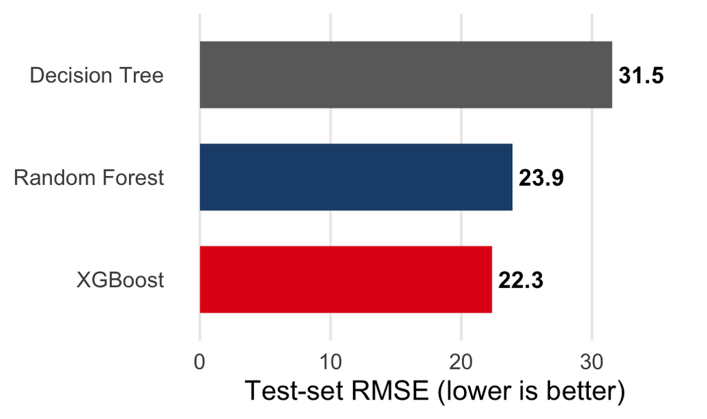

## Tree, forest, boosting: what’s the difference?

I · kNN + CVII · TreesForestsBoostingWrap-up

|  | One tree | Random forest | Boosting |
| --- | --- | --- | --- |
| **In the game** | "Pop?", then "lyrics?" | Three friends who each saw part of the table, voting | A relay: each friend aimed at the last one's mistakes |
| **How the trees are grown** | One, until the brakes stop it | 1,000 at once, independently: each on a resample, random columns | 1,000 small ones in turn, each on the leftovers |
| **How they're combined** | No combining | Average (or vote) | Sum, each with a small say |
| **The knobs** | `tree_depth`, `min_n`, `cost_complexity` | `trees`, `mtry` | `trees`, `learn_rate`, `mtry` |
| **Can you read it?** | Yes: a flow chart | No | No |
| **Test RMSE** (train) | 31.5 (27.5) | 23.9 (6.6) | 22.3 (3.6) |

Mind the gap An ensemble’s training error is always tiny: it has seen every row many times. The test set is the honest number. Part of the gap is **time**: prices rose in 2017–2018.

Nothing was tuned 1,000 trees, `mtry` 7, learning rate 0.1: rules of thumb. Part I’s `tune()` and cross-validation are how you’d do better.

## Summary

I · kNN + CVII · TreesForestsBoostingWrap-up

**1**A **hyperparameter** is a setting you choose, not one `fit()` estimates: the number of neighbours, the depth of a tree, the number of trees, the learning rate. Choose it by **cross-validation**: cut the training set into folds, score every candidate on held-out folds, average, pick. The **test set stays sealed** until the end. In code: `vfold_cv()`, `tune()`, `tune_grid()`, `select_best()`, `finalize_workflow()`

**2****k nearest neighbours** is the estate agent's comparables: the k most similar training rows vote. Small k is jagged (k = 1 memorises), large k is smooth. A **decision tree** is the Swiftie game: the question that sorts cleanest, then again inside each group, and stop before you invent a question for one person (L)

**3****Ensembles** fix the tree's instability. A **random forest** is a crowd that doesn't talk: many trees, each on resampled rows with a random handful of features, averaged. **Boosting** is a relay: small trees in turn, each aimed at what the last ones got wrong, summed. Both beat one tree; neither can be read like one

**Question:** you have the 2019 prices. Which model do you deploy, and how would you check whether the forest’s training RMSE of $7 means anything?

## Further reading

- The completed notebook goes up after class.
- [*An Introduction to Statistical Learning*](https://www.statlearning.com): 5.1 (cross-validation), 8.1–8.2 (trees, bagging, random forests, boosting). Free PDF.
- [*Tidy Modeling with R*](https://www.tmwr.org): chapters 10 (resampling), 12 (tuning) and 13 (grid search), with today’s functions.
- The [tidymodels “Get started” guides](https://www.tidymodels.org/start/): recipes, resampling and tuning, each in half an hour.

## 30 seconds of feedback

[figure not shown]

How was today’s lab? Scan the code, or open forms.gle/i3uobCAaGmkzf1ns7. It takes 30 seconds and changes what next week looks like.